# Assignment_3

Tejasvin

2024-03-10

## Summary

I examined the correlations between “Online,” “CC,” and “Loan” in the training data using pivot tables. I used naive Bayes modeling to estimate the likelihood of loan approval based on credit card possession and online banking behavior. I also calculated some important conditional probabilities. Finally, I evaluated the accuracy of my results by comparing them against other sources.

```r
# loading the required packages.

library(dplyr)
library(readr)
```

```r
# Loading the data set into R.

bank <- read_csv("./UniversalBank.csv")
head(bank)
```

```
## # A tibble: 6 × 14
##      ID   Age Experience Income `ZIP Code` Family CCAvg Education Mortgage
##   <dbl> <dbl>      <dbl>  <dbl>      <dbl>  <dbl> <dbl>     <dbl>    <dbl>
## 1     1    25          1     49      91107      4   1.6         1        0
## 2     2    45         19     34      90089      3   1.5         1        0
## 3     3    39         15     11      94720      1   1           1        0
## 4     4    35          9    100      94112      1   2.7         2        0
## 5     5    35          8     45      91330      4   1           2        0
## 6     6    37         13     29      92121      4   0.4         2      155
## # ℹ 5 more variables: `Personal Loan` <dbl>, `Securities Account` <dbl>,
## #   `CD Account` <dbl>, Online <dbl>, CreditCard <dbl>
```

```r
# Adding a new data frame and altering the col name.

colnames(bank)[10] ="PersonalLoan"
bankdf<- bank[c(10,13,14)]
```

```r
# Creating proportionate frequency tables and configuring the plotting parameters.

library(Amelia) # Loading the required package.
data_perc1 <- t(prop.table(table(bankdf$Online)))
data_perc2 <- t(prop.table(table(bankdf$CreditCard)))
data_perc3 <- t(prop.table(table(bankdf$PersonalLoan)))
par(mar = c(1, 1, 1, 1))
```

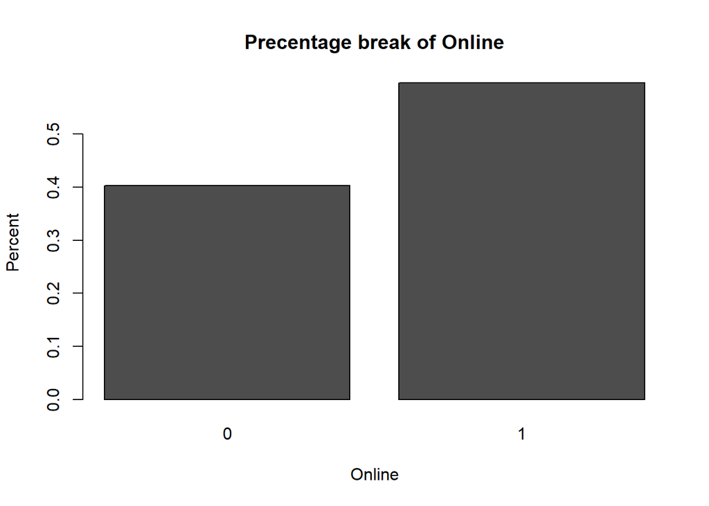

```r
# Building a bar chart to show the value for online, loan, and credit card transactions.

barplot(data_perc1, ylab = "Percent", xlab = "Online", main = "Precentage break of Online")
```

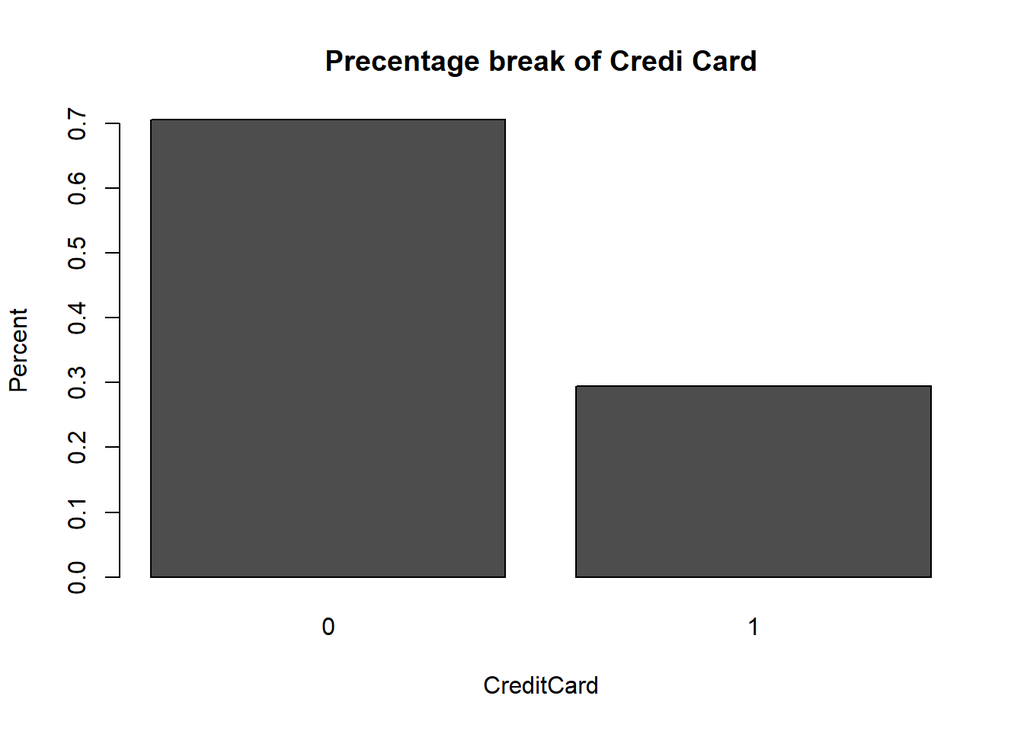

```r
barplot(data_perc2, ylab = "Percent", xlab = "CreditCard", main = "Precentage break of Credi Card")
```

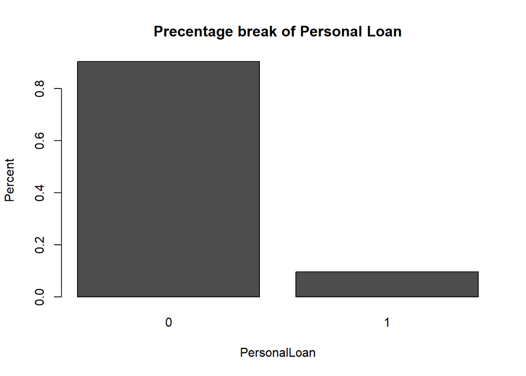

```r
barplot(data_perc3, ylab = "Percent", xlab = "PersonalLoan", main = "Precentage break of Personal Loan")
```

```r
bankdf$PersonalLoan <- as.factor(bankdf$PersonalLoan)
bankdf$Online <- as.factor(bankdf$Online)
bankdf$CreditCard <- as.factor(bankdf$CreditCard)
```

```r
# Separating data for validation and testing.

set.seed(123)
train.index <- sample(row.names(bankdf), 0.6*dim(bank)[1])
valid.index <- setdiff(row.names(bankdf), train.index)
train.df <- bankdf[train.index, ]
valid.df <- bankdf[valid.index, ]
```

```r
# Loading the required packages.

library(lessR)
library(caTools)
library(reshape2)
library(melt)
library(reshape)
library(data.table)
```

A. Pivot table was created using the training data set to display the count.

B. The calculated probability of loan acceptance is very low at 0.030.

C. Two separate pivot tables were created for the training data.

```r
# Summarizing statistics and transforming the data set into a long format.

train.mlt = melt(train.df,id=c("CreditCard","PersonalLoan"),variable= "Online")
train.dcast = dcast(train.mlt,CreditCard+PersonalLoan~Online)
train.dcast
```

```
##   CreditCard PersonalLoan Online
## 1          0            0   1930
## 2          0            1    187
## 3          1            0    792
## 4          1            1     91
```

```r
# Count derived from train.melt and train.dcast variables (91/3000) The probability of taking out a loan is a very low.030.

(91/3000)
```

```
## [1] 0.03033333
```

```r
t.df<-train.df %>%
  group_by(CreditCard,PersonalLoan)%>%
  summarise(count = n())
t.df
```

```
## # A tibble: 4 × 3
## # Groups:   CreditCard [2]
##   CreditCard PersonalLoan count
##   <fct>      <fct>        <int>
## 1 0          0             1930
## 2 0          1              187
## 3 1          0              792
## 4 1          1               91
```

```r
#The provided code counts the occurrences of various conditions related to "PersonalLoan," "Online," and "CreditCard" in the 'train.df' data frame and computes the probability of loan acceptance given both "Credit Card" and "Personal Loan" are 1 ({prob.loan.accp}).


loan.accp <- filter(t.df,(CreditCard==1 & PersonalLoan==1))
prob.loan.accp<- loan.accp$count/sum(t.df$count)
prob.loan.accp
```

```
## [1] 0.03033333
```

```r
sum(train.df$PersonalLoan == 1 & train.df$Online == 1)
```

```
## [1] 179
```

```r
sum(train.df$PersonalLoan == 1 & train.df$Online == 0)
```

```
## [1] 99
```

```r
sum(train.df$PersonalLoan == 0 & train.df$Online == 1)
```

```
## [1] 1620
```

```r
sum(train.df$PersonalLoan == 0 & train.df$Online == 0)
```

```
## [1] 1102
```

```r
sum(train.df$PersonalLoan == 1 & train.df$CreditCard == 1)
```

```
## [1] 91
```

```r
sum(train.df$PersonalLoan == 1 & train.df$CreditCard == 0)
```

```
## [1] 187
```

```r
sum(train.df$PersonalLoan == 0 & train.df$CreditCard == 1)
```

```
## [1] 792
```

```r
sum(train.df$PersonalLoan == 0 & train.df$CreditCard == 0)
```

```
## [1] 1930
```

```r
#This code creates a new data frame called 'cc.func' from the results of counting the occurrences of each unique value in the "CreditCard" column in the 'train.df' data frame. The resulting data frame, 'cc.func', has two columns: "count" (the corresponding count of occurrences for each unique value) and "CreditCard" (unique values in the original "CreditCard" column).

library(dplyr) # Loading required library.

cc.func <-train.df %>%
  group_by(CreditCard)%>%
  summarise(count = n())
cc.func
```

```
## # A tibble: 2 × 2
##   CreditCard count
##   <fct>      <int>
## 1 0           2117
## 2 1            883
```

```r
#This code generates a summary data frame 'pl.func' containing counts for each distinct value in the 'train.df' dataset's "PersonalLoan" column.

pl.func <-train.df %>%
  group_by(PersonalLoan)%>%
  summarise(count = n())
pl.func
```

```
## # A tibble: 2 × 2
##   PersonalLoan count
##   <fct>        <int>
## 1 0             2722
## 2 1              278
```

```r
#The 'train.df' dataset's designated columns contain unique combinations or values that are counted in contingency tables created by these lines of code.

table(train.df[,c(3,1)])
```

```
##           PersonalLoan
## CreditCard    0    1
##          0 1930  187
##          1  792   91
```

```r
table(train.df[,c(2,1)])
```

```
##       PersonalLoan
## Online    0    1
##      0 1102   99
##      1 1620  179
```

```r
table(train.df[,c(1)])
```

```
## PersonalLoan
##    0    1
## 2722  278
```

D. Creating the conditional probability

```r
# With a focus on various combinations of "CreditCard," "Online," and "PersonalLoan" status, the code determines the proportions of particular conditions within the 'train.df' dataset.


a <-count(filter(train.df,(CreditCard==1 & PersonalLoan==1)))/count(filter(train.df,PersonalLoan==1))
a
```

```
##           n
## 1 0.3273381
```

```r
b <-count(filter(train.df,(Online==1 & PersonalLoan==1)))/count(filter(train.df,(PersonalLoan==1)))
b
```

```
##           n
## 1 0.6438849
```

```r
c<-count(filter(train.df,(PersonalLoan==1)))/count(filter(train.df))
c
```

```
##            n
## 1 0.09266667
```

```r
d<-count(filter(train.df,(CreditCard==1 & PersonalLoan==0)))/count(filter(train.df, PersonalLoan ==0))
d
```

```
##           n
## 1 0.2909625
```

```r
e <-count(filter(train.df,(Online==1 & PersonalLoan==0)))/count(filter(train.df, PersonalLoan ==0))
e
```

```
##           n
## 1 0.5951506
```

```r
f <-count(filter(train.df,(PersonalLoan==0)))/count(filter(train.df))
f
```

```
##           n
## 1 0.9073333
```

E.The probability Naive Bayes (if loan, credit card and online are = 1)

```r
naiveBayes.prob<-(a*b*c)/((a*b*c)+(d*e*f))
naiveBayes.prob
```

```
##           n
## 1 0.1105637
```

```r
# Using features from columns 1 through 3 in the naive bayes function for personal loans.

library(e1071) #Loading required package.
navie.t = train.df[,c(1:3)]
naive.v = valid.df[,c(1:3)]
model.b <- naiveBayes(PersonalLoan~.,data=navie.t)
model.b
```

```
##
## Naive Bayes Classifier for Discrete Predictors
##
## Call:
## naiveBayes.default(x = X, y = Y, laplace = laplace)
##
## A-priori probabilities:
## Y
##          0          1
## 0.90733333 0.09266667
##
## Conditional probabilities:
##    Online
## Y           0         1
##   0 0.4048494 0.5951506
##   1 0.3561151 0.6438849
##
##    CreditCard
## Y           0         1
##   0 0.7090375 0.2909625
##   1 0.6726619 0.3273381
```

```r
p_cc_1 <- 0.2935154
p_online_1 <- 0.6075085
p_loan_1 <- 0.09766667

p_nb <- (p_cc_1 * p_online_1 * p_loan_1) /
                 (p_cc_1 * p_online_1 * p_loan_1 +
                  0.3924915 * 0.7064846 * (1 - p_loan_1))

p_nb
```

```
## [1] 0.06507392
```

Testing Validation Model

```r
#This code makes predictions on the validation dataset 'naive.v' using the trained naive Bayes model 'model.b'. generating a confusion matrix 'conf_mat' and utilizing 'confusionMatrix' to calculate summary statistics in order to assess how well the model predicts "PersonalLoan."


pre <- predict(model.b, naive.v)
summary(pre)
```

```
##    0    1
## 2000    0
```

```r
conf_mat <- table(valid.df$PersonalLoan,pre)
print(conf_mat)
```

```
##    pre
##        0    1
##   0 1798    0
##   1  202    0
```

```r
library(caret)
confusionMatrix(conf_mat)
```

```
## Confusion Matrix and Statistics
##
##    pre
##        0    1
##   0 1798    0
##   1  202    0
##
##                Accuracy : 0.899
##                  95% CI : (0.885, 0.9119)
##     No Information Rate : 1
##     P-Value [Acc > NIR] : 1
##
##                   Kappa : 0
##
##  Mcnemar's Test P-Value : <0.0000000000000002
##
##             Sensitivity : 0.899
##             Specificity :    NA
##          Pos Pred Value :    NA
##          Neg Pred Value :    NA
##              Prevalence : 1.000
##          Detection Rate : 0.899
##    Detection Prevalence : 0.899
##       Balanced Accuracy :    NA
##
##        'Positive' Class : 0
##
```